# lifeanalysis2

```python
import pandas as pd
import seaborn as sns
import numpy as np
import matplotlib.pyplot as plt
import math
import scipy
import pmdarima as pm
#Загружаем библиотеки необходимые для загрузки данных и работы с ними
```

```python
df = pd.read_excel('/Users/Elvira/life1.xlsx')
#загружаем данные
```

```python
df.head()
#Смотрим перые наблюдения для того чтобы понять в каком виде загрузились наши данные
```

|  | Country | Region | Infant_deaths | Under_five_deaths | Adult_mortality | Alcohol_consumption | Hepatitis_B | Measles | BMI | Polio | Diphtheria | Incidents_HIV | GDP_per_capita | Population_mln | Thinness_ten_nineteen_years | Thinness_five_nine_years | Schooling | Economy_status_Developed | Economy_status_Developing | Life_expectancy |
| --- | --- | --- | --- | --- | --- | --- | --- | --- | --- | --- | --- | --- | --- | --- | --- | --- | --- | --- | --- | --- |
| 0 | Turkiye | Middle East | 11.1 | 13.0 | 105.8240 | 1.32 | 97 | 65 | 27.8 | 97 | 97 | 0.08 | 11006 | 78.53 | 4.9 | 4.8 | 7.8 | 0 | 1 | 76.5 |
| 1 | Spain | European Union | 2.7 | 3.3 | 57.9025 | 10.35 | 97 | 94 | 26.0 | 97 | 97 | 0.09 | 25742 | 46.44 | 0.6 | 0.5 | 9.7 | 1 | 0 | 82.8 |
| 2 | Russian Federation | Rest of Europe | 6.6 | 8.2 | 223.0000 | 8.06 | 97 | 97 | 26.2 | 97 | 97 | 0.08 | 9313 | 144.10 | 2.3 | 2.3 | 12.0 | 0 | 1 | 71.2 |
| 3 | Cameroon | Africa | 57.0 | 88.0 | 340.1265 | 4.55 | 84 | 64 | 24.3 | 77 | 84 | 1.12 | 1383 | 23.30 | 5.6 | 5.5 | 6.1 | 0 | 1 | 57.6 |
| 4 | Gambia, The | Africa | 39.7 | 59.8 | 261.7065 | 2.69 | 97 | 64 | 23.9 | 96 | 97 | 0.96 | 661 | 2.09 | 7.3 | 7.2 | 3.4 | 0 | 1 | 60.9 |

```python
df.columns.tolist()
#смотрим список переменных имеющихся в данных
```

```
['Country',
 'Region',
 'Infant_deaths',
 'Under_five_deaths',
 'Adult_mortality',
 'Alcohol_consumption',
 'Hepatitis_B',
 'Measles',
 'BMI',
 'Polio',
 'Diphtheria',
 'Incidents_HIV',
 'GDP_per_capita',
 'Population_mln',
 'Thinness_ten_nineteen_years',
 'Thinness_five_nine_years',
 'Schooling',
 'Economy_status_Developed',
 'Economy_status_Developing',
 'Life_expectancy']
```

```python
df.dtypes
#Смотрим какие типы данных имеют переменные
```

```
Country                         object
Region                          object
Infant_deaths                  float64
Under_five_deaths              float64
Adult_mortality                float64
Alcohol_consumption            float64
Hepatitis_B                      int64
Measles                          int64
BMI                            float64
Polio                            int64
Diphtheria                       int64
Incidents_HIV                  float64
GDP_per_capita                   int64
Population_mln                 float64
Thinness_ten_nineteen_years    float64
Thinness_five_nine_years       float64
Schooling                      float64
Economy_status_Developed         int64
Economy_status_Developing        int64
Life_expectancy                float64
dtype: object
```

```python
len(df.dropna())
#Для того чтобы узнать есть ли пропущенные значения,узнаем длинну строки
```

```
179
```

```python
df.info()
#статистика пропущенных значений для каждого показания-non-null-значит пропущенных значений нет
```

```
<class 'pandas.core.frame.DataFrame'>
RangeIndex: 179 entries, 0 to 178
Data columns (total 20 columns):
 #   Column                       Non-Null Count  Dtype
---  ------                       --------------  -----
 0   Country                      179 non-null    object
 1   Region                       179 non-null    object
 2   Infant_deaths                179 non-null    float64
 3   Under_five_deaths            179 non-null    float64
 4   Adult_mortality              179 non-null    float64
 5   Alcohol_consumption          179 non-null    float64
 6   Hepatitis_B                  179 non-null    int64
 7   Measles                      179 non-null    int64
 8   BMI                          179 non-null    float64
 9   Polio                        179 non-null    int64
 10  Diphtheria                   179 non-null    int64
 11  Incidents_HIV                179 non-null    float64
 12  GDP_per_capita               179 non-null    int64
 13  Population_mln               179 non-null    float64
 14  Thinness_ten_nineteen_years  179 non-null    float64
 15  Thinness_five_nine_years     179 non-null    float64
 16  Schooling                    179 non-null    float64
 17  Economy_status_Developed     179 non-null    int64
 18  Economy_status_Developing    179 non-null    int64
 19  Life_expectancy              179 non-null    float64
dtypes: float64(11), int64(7), object(2)
memory usage: 28.1+ KB
```

```python
df.describe()
# смотрим описательную статистику
```

|  | Infant_deaths | Under_five_deaths | Adult_mortality | Alcohol_consumption | Hepatitis_B | Measles | BMI | Polio | Diphtheria | Incidents_HIV | GDP_per_capita | Population_mln | Thinness_ten_nineteen_years | Thinness_five_nine_years | Schooling | Economy_status_Developed | Economy_status_Developing | Life_expectancy |
| --- | --- | --- | --- | --- | --- | --- | --- | --- | --- | --- | --- | --- | --- | --- | --- | --- | --- | --- |
| count | 179.000000 | 179.000000 | 179.00000 | 179.000000 | 179.000000 | 179.000000 | 179.000000 | 179.00000 | 179.000000 | 179.000000 | 179.000000 | 179.000000 | 179.000000 | 179.000000 | 179.000000 | 179.000000 | 179.000000 | 179.000000 |
| mean | 23.558659 | 31.680447 | 163.66757 | 4.728994 | 87.100559 | 80.229050 | 25.596089 | 88.26257 | 87.916201 | 0.609777 | 12617.296089 | 40.087933 | 4.549721 | 4.593855 | 8.360894 | 0.206704 | 0.793296 | 71.463687 |
| std | 21.487508 | 32.217096 | 89.95447 | 3.743322 | 14.167575 | 16.185999 | 2.191669 | 13.02432 | 14.693831 | 1.621318 | 17719.612926 | 146.506422 | 4.115992 | 4.195546 | 3.146986 | 0.406077 | 0.406077 | 7.832270 |
| min | 1.800000 | 2.300000 | 49.38400 | 0.000000 | 22.000000 | 21.000000 | 20.500000 | 37.00000 | 16.000000 | 0.010000 | 306.000000 | 0.090000 | 0.100000 | 0.100000 | 1.400000 | 0.000000 | 0.000000 | 50.900000 |
| 25% | 6.650000 | 7.850000 | 90.78575 | 1.360000 | 82.500000 | 64.000000 | 23.800000 | 85.00000 | 85.500000 | 0.080000 | 1690.000000 | 2.215000 | 1.500000 | 1.500000 | 5.950000 | 0.000000 | 1.000000 | 66.300000 |
| 50% | 15.200000 | 17.500000 | 146.51950 | 4.040000 | 92.000000 | 84.000000 | 26.200000 | 93.00000 | 93.000000 | 0.140000 | 5391.000000 | 9.110000 | 3.500000 | 3.400000 | 8.700000 | 0.000000 | 1.000000 | 73.000000 |
| 75% | 36.550000 | 49.950000 | 215.64925 | 7.760000 | 97.000000 | 94.000000 | 27.000000 | 97.00000 | 97.000000 | 0.370000 | 14274.500000 | 27.445000 | 6.500000 | 6.450000 | 11.050000 | 0.000000 | 1.000000 | 76.850000 |
| max | 95.100000 | 140.200000 | 513.47550 | 16.720000 | 99.000000 | 99.000000 | 32.100000 | 99.00000 | 99.000000 | 14.300000 | 105462.000000 | 1379.860000 | 26.700000 | 27.300000 | 14.100000 | 1.000000 | 1.000000 | 83.800000 |

```python
#удаляем показатели которые не нужны нам при анализe
```

```python
del df['Region']
```

```python
del df["Country"]
```

```python
#загружаем библиотеки которые могут пригодиться нам для построения модели
```

```python
from sklearn.linear_model import LinearRegression
```

```python
import statsmodels.api as sm
```

```python
X = df.drop('Life_expectancy',axis=1)
y = df['Life_expectancy']
X
# задаем Х и У ,
#из X удаляем показатель, который взяли за Y ,axis означает что мы "выкидываем" столбик
```

|  | Infant_deaths | Under_five_deaths | Adult_mortality | Alcohol_consumption | Hepatitis_B | Measles | BMI | Polio | Diphtheria | Incidents_HIV | GDP_per_capita | Population_mln | Thinness_ten_nineteen_years | Thinness_five_nine_years | Schooling | Economy_status_Developed | Economy_status_Developing |
| --- | --- | --- | --- | --- | --- | --- | --- | --- | --- | --- | --- | --- | --- | --- | --- | --- | --- |
| 0 | 11.1 | 13.0 | 105.8240 | 1.32 | 97 | 65 | 27.8 | 97 | 97 | 0.08 | 11006 | 78.53 | 4.9 | 4.8 | 7.8 | 0 | 1 |
| 1 | 2.7 | 3.3 | 57.9025 | 10.35 | 97 | 94 | 26.0 | 97 | 97 | 0.09 | 25742 | 46.44 | 0.6 | 0.5 | 9.7 | 1 | 0 |
| 2 | 6.6 | 8.2 | 223.0000 | 8.06 | 97 | 97 | 26.2 | 97 | 97 | 0.08 | 9313 | 144.10 | 2.3 | 2.3 | 12.0 | 0 | 1 |
| 3 | 57.0 | 88.0 | 340.1265 | 4.55 | 84 | 64 | 24.3 | 77 | 84 | 1.12 | 1383 | 23.30 | 5.6 | 5.5 | 6.1 | 0 | 1 |
| 4 | 39.7 | 59.8 | 261.7065 | 2.69 | 97 | 64 | 23.9 | 96 | 97 | 0.96 | 661 | 2.09 | 7.3 | 7.2 | 3.4 | 0 | 1 |
| ... | ... | ... | ... | ... | ... | ... | ... | ... | ... | ... | ... | ... | ... | ... | ... | ... | ... |
| 174 | 14.8 | 17.2 | 91.3430 | 1.50 | 98 | 98 | 26.3 | 98 | 98 | 0.04 | 4095 | 11.18 | 6.5 | 6.4 | 7.0 | 0 | 1 |
| 175 | 16.4 | 19.1 | 141.5540 | 6.21 | 87 | 83 | 26.7 | 87 | 87 | 0.40 | 17318 | 30.08 | 1.6 | 1.5 | 10.1 | 0 | 1 |
| 176 | 54.6 | 65.8 | 251.7490 | 0.32 | 84 | 82 | 24.0 | 84 | 84 | 0.22 | 2653 | 0.91 | 5.6 | 5.4 | 4.1 | 0 | 1 |
| 177 | 16.6 | 19.4 | 148.4805 | 3.72 | 98 | 83 | 27.2 | 99 | 98 | 0.11 | 2050 | 6.22 | 1.8 | 1.7 | 6.5 | 0 | 1 |
| 178 | 6.5 | 7.6 | 66.6840 | 1.53 | 98 | 99 | 24.8 | 98 | 98 | 0.05 | 22634 | 1.37 | 6.2 | 6.1 | 9.3 | 0 | 1 |

179 rows × 17 columns

```python
y
```

```
0      76.5
1      82.8
2      71.2
3      57.6
4      60.9
       ...
174    75.9
175    72.6
176    64.1
177    73.6
178    76.8
Name: Life_expectancy, Length: 179, dtype: float64
```

```python
X = sm.add_constant(X)
#добавляем константу к переменным-предикторам
```

```
                            OLS Regression Results
==============================================================================
Dep. Variable:        Life_expectancy   R-squared:                       0.971
Model:                            OLS   Adj. R-squared:                  0.968
Method:                 Least Squares   F-statistic:                     342.4
Date:                Wed, 19 Apr 2023   Prob (F-statistic):          6.80e-116
Time:                        12:17:45   Log-Likelihood:                -304.19
No. Observations:                 179   AIC:                             642.4
Df Residuals:                     162   BIC:                             696.6
Df Model:                          16
Covariance Type:            nonrobust
===============================================================================================
                                  coef    std err          t      P>|t|      [0.025      0.975]
-----------------------------------------------------------------------------------------------
const                          56.6242      1.658     34.150      0.000      53.350      59.898
Infant_deaths                  -0.0115      0.040     -0.285      0.776      -0.091       0.068
Under_five_deaths              -0.0829      0.027     -3.055      0.003      -0.136      -0.029
Adult_mortality                -0.0500      0.003    -15.064      0.000      -0.057      -0.043
Alcohol_consumption             0.0911      0.046      1.979      0.050       0.000       0.182
Hepatitis_B                    -0.0278      0.025     -1.107      0.270      -0.077       0.022
Measles                         0.0115      0.009      1.322      0.188      -0.006       0.029
BMI                            -0.1292      0.076     -1.695      0.092      -0.280       0.021
Polio                          -0.0101      0.024     -0.417      0.677      -0.058       0.038
Diphtheria                      0.0283      0.029      0.969      0.334      -0.029       0.086
Incidents_HIV                   0.1344      0.094      1.430      0.155      -0.051       0.320
GDP_per_capita               3.301e-05   9.33e-06      3.539      0.001    1.46e-05    5.14e-05
Population_mln                 -0.0002      0.001     -0.246      0.806      -0.002       0.001
Thinness_ten_nineteen_years    -0.0498      0.119     -0.417      0.677      -0.285       0.186
Thinness_five_nine_years        0.0210      0.120      0.175      0.862      -0.217       0.259
Schooling                       0.0288      0.076      0.380      0.705      -0.121       0.178
Economy_status_Developed       28.6809      0.852     33.666      0.000      26.999      30.363
Economy_status_Developing      27.9432      0.870     32.124      0.000      26.226      29.661
==============================================================================
Omnibus:                        0.206   Durbin-Watson:                   1.924
Prob(Omnibus):                  0.902   Jarque-Bera (JB):                0.366
Skew:                           0.016   Prob(JB):                        0.833
Kurtosis:                       2.781   Cond. No.                     2.18e+20
==============================================================================

Notes:
[1] Standard Errors assume that the covariance matrix of the errors is correctly specified.
[2] The smallest eigenvalue is 1.78e-30. This might indicate that there are
strong multicollinearity problems or that the design matrix is singular.
```

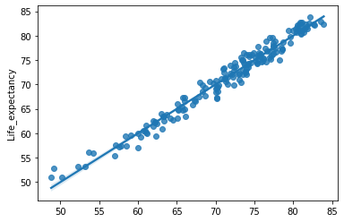

```python
model = sm.OLS(y, X).fit()
print(model.summary())
r=model.predict(X)
r=np.array(model)
sns.regplot(model.fittedvalues.copy(), y)
plt.show()
# statsmodels сокращенно sm,обучаем модель.Линейная регрессия
```

Данный код выполняет линейную регрессионную модель (OLS) для зависимой переменной y и независимой переменной X.

Первая строка создает объект модели с помощью функции OLS из библиотеки statsmodels.

Вторая строка выводит сводку результатов модели, которая содержит информацию о коэффициентах регрессии, статистических показателях, оценках значимости и т.д.

Третья строка создает переменную r, которая содержит предсказания модели для наблюдений в X.

Четвертая и пятая строки создают график рассеяния с линией тренда для сравнения фактических данных y с предсказаниями модели model.fittedvalues.copy(). пятая строка plt.show(), показывает график.

Интерпретация вывода модели и графика: Зависимой здесь является пременная Life_expectancy Использовался метод наименьших квадратов R-squared (коэффициент детерминации) равен 0.971, что означает, что 97.1% вариации зависимой переменной (y) может быть объяснено независимыми переменными (X), используемыми в модели.

Adj. R-squared (скорректированный коэффициент детерминации) равен 0.968. Этот показатель учитывает количество независимых переменных и корректирует коэффициент детерминации в соответствии с числом используемых переменных. Обычно этот показатель более надежен, чем просто коэффициент детерминации, поскольку он может уменьшаться при добавлении "лишних" переменных, которые не вносят значительный вклад в модель.

Общее значение коэффициента детерминации в 0.97 указывает на то, что данная линейная регрессионная модель хорошо описывает отношение между зависимыми и независимыми переменными.Модель получилось точной,чем ближе R квадрат к единице,тем более точная модель.

Нам необходимо посмотреть на Столбец t,он содержит t-статистику для проверки гипотезы о значимости коэффициентов регрессии. Чем больше значение t, тем более значимый коэффициент регрессии.ecли t значение больше 2-х то показатель значимый. Значения статистической значимости (P>|t|) показывают вероятность получения таких или еще более экстремальных результатов, если коэффициент регрессии действительно равен нулю. Если значение P>|t| меньше заданного уровня значимости (обычно 0.05), то коэффициент считается статистически значимым. В данном случае значимыми переменными являются 'Under_five_deaths','Adult_mortality','GDP_per_capita','Economy_status_Developed','Economy_status_Developing'

```python
# выбрали значимые переменные.К ним относят те,t значение которых больше 2-х:
X2 = df[['Under_five_deaths','Adult_mortality','GDP_per_capita','Economy_status_Developed','Economy_status_Developing']]
X2
```

|  | Under_five_deaths | Adult_mortality | GDP_per_capita | Economy_status_Developed | Economy_status_Developing |
| --- | --- | --- | --- | --- | --- |
| 0 | 13.0 | 105.8240 | 11006 | 0 | 1 |
| 1 | 3.3 | 57.9025 | 25742 | 1 | 0 |
| 2 | 8.2 | 223.0000 | 9313 | 0 | 1 |
| 3 | 88.0 | 340.1265 | 1383 | 0 | 1 |
| 4 | 59.8 | 261.7065 | 661 | 0 | 1 |
| ... | ... | ... | ... | ... | ... |
| 174 | 17.2 | 91.3430 | 4095 | 0 | 1 |
| 175 | 19.1 | 141.5540 | 17318 | 0 | 1 |
| 176 | 65.8 | 251.7490 | 2653 | 0 | 1 |
| 177 | 19.4 | 148.4805 | 2050 | 0 | 1 |
| 178 | 7.6 | 66.6840 | 22634 | 0 | 1 |

179 rows × 5 columns

```python
df.corr()
# смотрим какие связаны,чтобы что-то убрать.Между игриком и иксом должна быть тесная взаимосвязь,
#а вот между другими показателями тесной связи быть не должно.
#функция вычисляет попарную корреляцию столбцов во фрейме данных.
#Он возвращает коэффициенты корреляции.Значения могут быть от -1 до 1.1 указывает на положительную корреляцию и зависимость двух переменных друг от друга,
#а -1 указывает отрецательную корреляцию.Если две значимые переменные зависят друг от друга тоодну из них необходимо исключить.
```

|  | Infant_deaths | Under_five_deaths | Adult_mortality | Alcohol_consumption | Hepatitis_B | Measles | BMI | Polio | Diphtheria | Incidents_HIV | GDP_per_capita | Population_mln | Thinness_ten_nineteen_years | Thinness_five_nine_years | Schooling | Economy_status_Developed | Economy_status_Developing | Life_expectancy |
| --- | --- | --- | --- | --- | --- | --- | --- | --- | --- | --- | --- | --- | --- | --- | --- | --- | --- | --- |
| Infant_deaths | 1.000000 | 0.989986 | 0.853730 | -0.469252 | -0.506360 | -0.586110 | -0.592867 | -0.651938 | -0.581457 | 0.340959 | -0.514003 | 0.000248 | 0.496420 | 0.495402 | -0.801789 | -0.475722 | 0.475722 | -0.930565 |
| Under_five_deaths | 0.989986 | 1.000000 | 0.842293 | -0.439138 | -0.528690 | -0.584598 | -0.604017 | -0.665030 | -0.595354 | 0.312278 | -0.480795 | -0.006124 | 0.478948 | 0.471912 | -0.795649 | -0.434866 | 0.434866 | -0.921208 |
| Adult_mortality | 0.853730 | 0.842293 | 1.000000 | -0.291492 | -0.389637 | -0.533267 | -0.489581 | -0.525404 | -0.475836 | 0.590920 | -0.557919 | -0.040370 | 0.360255 | 0.356677 | -0.647072 | -0.477176 | 0.477176 | -0.949169 |
| Alcohol_consumption | -0.469252 | -0.439138 | -0.291492 | 1.000000 | 0.210243 | 0.314452 | 0.225911 | 0.288257 | 0.275656 | 0.017610 | 0.457051 | -0.020855 | -0.456268 | -0.459399 | 0.633264 | 0.679472 | -0.679472 | 0.448772 |
| Hepatitis_B | -0.506360 | -0.528690 | -0.389637 | 0.210243 | 1.000000 | 0.490537 | 0.202075 | 0.888665 | 0.943846 | -0.076765 | 0.176560 | 0.014297 | -0.123441 | -0.139880 | 0.344311 | 0.124289 | -0.124289 | 0.439799 |
| Measles | -0.586110 | -0.584598 | -0.533267 | 0.314452 | 0.490537 | 1.000000 | 0.419160 | 0.557136 | 0.530523 | -0.184398 | 0.347716 | -0.034261 | -0.280677 | -0.304848 | 0.555632 | 0.312427 | -0.312427 | 0.583813 |
| BMI | -0.592867 | -0.604017 | -0.489581 | 0.225911 | 0.202075 | 0.419160 | 1.000000 | 0.288207 | 0.234782 | -0.119054 | 0.279884 | -0.176013 | -0.556483 | -0.582974 | 0.606229 | 0.189655 | -0.189655 | 0.527398 |
| Polio | -0.651938 | -0.665030 | -0.525404 | 0.288257 | 0.888665 | 0.557136 | 0.288207 | 1.000000 | 0.929629 | -0.134215 | 0.315542 | 0.015497 | -0.221284 | -0.237534 | 0.501955 | 0.263734 | -0.263734 | 0.591097 |
| Diphtheria | -0.581457 | -0.595354 | -0.475836 | 0.275656 | 0.943846 | 0.530523 | 0.234782 | 0.929629 | 1.000000 | -0.122327 | 0.301799 | 0.012881 | -0.182116 | -0.210781 | 0.437217 | 0.256192 | -0.256192 | 0.537085 |
| Incidents_HIV | 0.340959 | 0.312278 | 0.590920 | 0.017610 | -0.076765 | -0.184398 | -0.119054 | -0.134215 | -0.122327 | 1.000000 | -0.160381 | -0.057608 | 0.089626 | 0.083533 | -0.173505 | -0.169225 | 0.169225 | -0.450129 |
| GDP_per_capita | -0.514003 | -0.480795 | -0.557919 | 0.457051 | 0.176560 | 0.347716 | 0.279884 | 0.315542 | 0.301799 | -0.160381 | 1.000000 | -0.038493 | -0.375664 | -0.387740 | 0.599002 | 0.683775 | -0.683775 | 0.629353 |
| Population_mln | 0.000248 | -0.006124 | -0.040370 | -0.020855 | 0.014297 | -0.034261 | -0.176013 | 0.015497 | 0.012881 | -0.057608 | -0.038493 | 1.000000 | 0.290657 | 0.287454 | -0.041226 | -0.041493 | 0.041493 | 0.015177 |
| Thinness_ten_nineteen_years | 0.496420 | 0.478948 | 0.360255 | -0.456268 | -0.123441 | -0.280677 | -0.556483 | -0.221284 | -0.182116 | 0.089626 | -0.375664 | 0.290657 | 1.000000 | 0.973136 | -0.567950 | -0.417261 | 0.417261 | -0.456334 |
| Thinness_five_nine_years | 0.495402 | 0.471912 | 0.356677 | -0.459399 | -0.139880 | -0.304848 | -0.582974 | -0.237534 | -0.210781 | 0.083533 | -0.387740 | 0.287454 | 0.973136 | 1.000000 | -0.564734 | -0.422648 | 0.422648 | -0.452249 |
| Schooling | -0.801789 | -0.795649 | -0.647072 | 0.633264 | 0.344311 | 0.555632 | 0.606229 | 0.501955 | 0.437217 | -0.173505 | 0.599002 | -0.041226 | -0.567950 | -0.564734 | 1.000000 | 0.606441 | -0.606441 | 0.767843 |
| Economy_status_Developed | -0.475722 | -0.434866 | -0.477176 | 0.679472 | 0.124289 | 0.312427 | 0.189655 | 0.263734 | 0.256192 | -0.169225 | 0.683775 | -0.041493 | -0.417261 | -0.422648 | 0.606441 | 1.000000 | -1.000000 | 0.568321 |
| Economy_status_Developing | 0.475722 | 0.434866 | 0.477176 | -0.679472 | -0.124289 | -0.312427 | -0.189655 | -0.263734 | -0.256192 | 0.169225 | -0.683775 | 0.041493 | 0.417261 | 0.422648 | -0.606441 | -1.000000 | 1.000000 | -0.568321 |
| Life_expectancy | -0.930565 | -0.921208 | -0.949169 | 0.448772 | 0.439799 | 0.583813 | 0.527398 | 0.591097 | 0.537085 | -0.450129 | 0.629353 | 0.015177 | -0.456334 | -0.452249 | 0.767843 | 0.568321 | -0.568321 | 1.000000 |

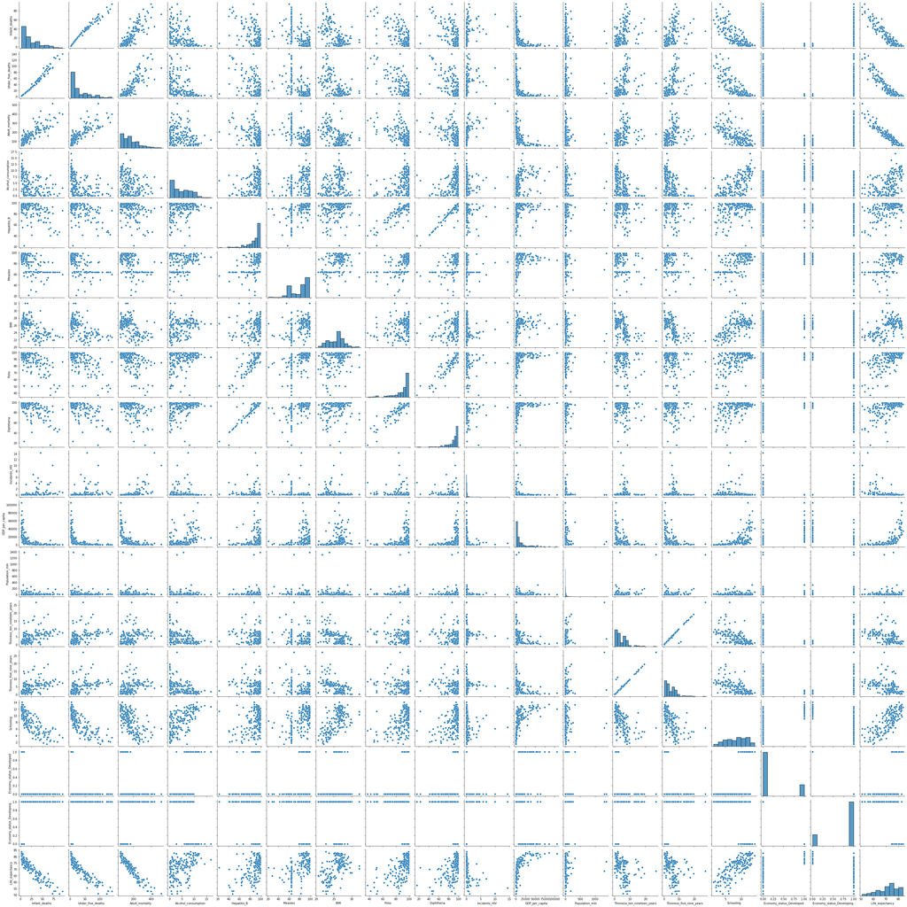

```python
sns.pairplot(df);
#Чтобы увидеть зависимость графическом виде используем pairplot() из seaborn.
#Нам нужно чтобы распределение было ненормальное.Так как здесь слишком много переменных смотреть неудобно
```

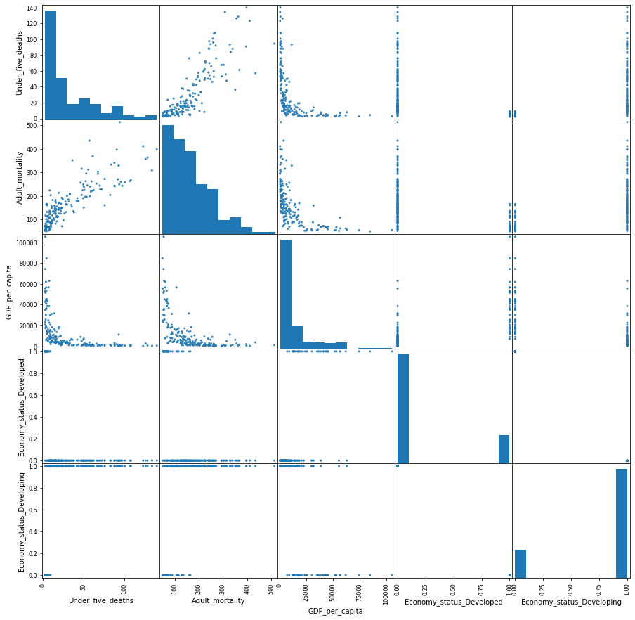

```python
from pandas.plotting import scatter_matrix
col=['Under_five_deaths','Adult_mortality','GDP_per_capita','Economy_status_Developed','Economy_status_Developing']
scatter_matrix(df[col], alpha=0.9, figsize=(15, 15));
#По сути происходит тоже самое,но показателей меньше поэтому мы можем лучше рассмотреть гистограммы.Видно что показатели распределены ненормально
```

```python
pip install pmdarima
```

```python
pip install adtk
```

```python
%run f2forecast.py
```

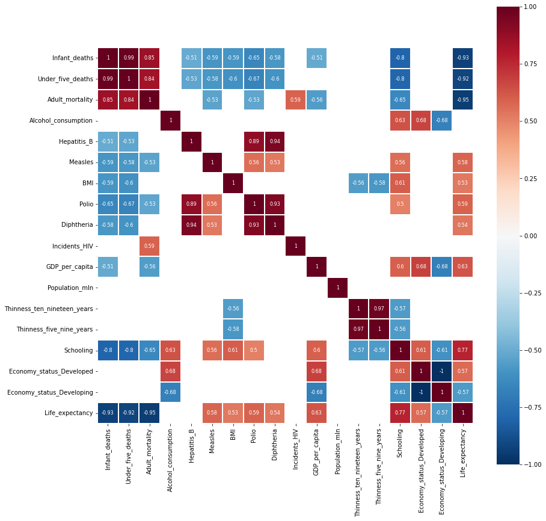

```python
h_map(df, 0.5)

#h_map() создает тепловую карту корреляционной матрицы и принимает пороговое значение 0,5
#визуалируем корреляции выше 0,5 или ниже -0,5.
#красным цветом выделяются положительные корреляции,синим цветом отрицательные корреляций,
#Более темными оттенками отображаются более сильные корреляции.
```

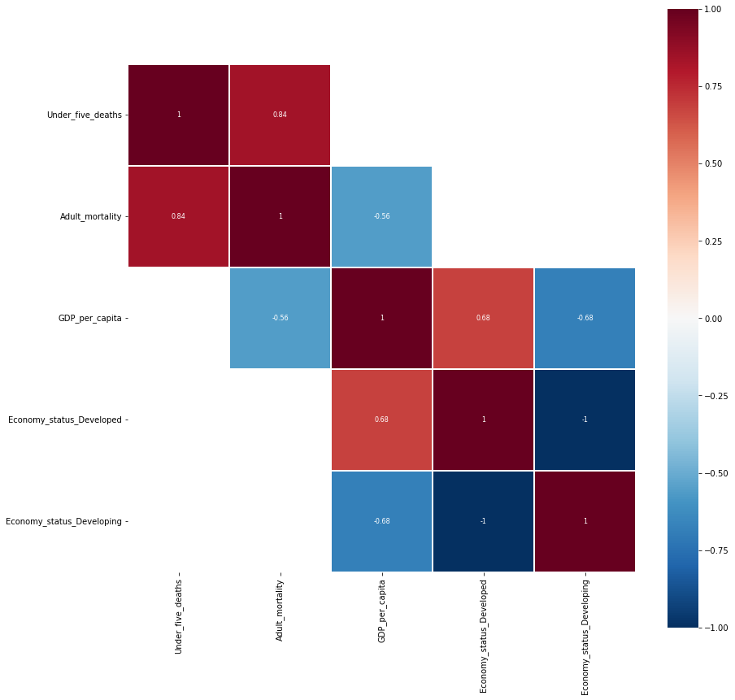

```python
h_map(X2, 0.5)
#визуалируем все значимые корреляции выше 0,5
```

```python
X3 =df[['Adult_mortality','Economy_status_Developed']]
#  убрали из значимых те переменные, которые тесно связаны
```

```python
#Снова обучаем модель:
```

```python
X3 = sm.add_constant(X3)
X3
#создаем константу
```

|  | const | Adult_mortality | Economy_status_Developed |
| --- | --- | --- | --- |
| 0 | 1.0 | 105.8240 | 0 |
| 1 | 1.0 | 57.9025 | 1 |
| 2 | 1.0 | 223.0000 | 0 |
| 3 | 1.0 | 340.1265 | 0 |
| 4 | 1.0 | 261.7065 | 0 |
| ... | ... | ... | ... |
| 174 | 1.0 | 91.3430 | 0 |
| 175 | 1.0 | 141.5540 | 0 |
| 176 | 1.0 | 251.7490 | 0 |
| 177 | 1.0 | 148.4805 | 0 |
| 178 | 1.0 | 66.6840 | 0 |

179 rows × 3 columns

```
                            OLS Regression Results
==============================================================================
Dep. Variable:        Life_expectancy   R-squared:                       0.918
Model:                            OLS   Adj. R-squared:                  0.917
Method:                 Least Squares   F-statistic:                     987.3
Date:                Wed, 19 Apr 2023   Prob (F-statistic):           2.18e-96
Time:                        12:09:08   Log-Likelihood:                -397.89
No. Observations:                 179   AIC:                             801.8
Df Residuals:                     176   BIC:                             811.3
Df Model:                           2
Covariance Type:            nonrobust
============================================================================================
                               coef    std err          t      P>|t|      [0.025      0.975]
--------------------------------------------------------------------------------------------
const                       83.3779      0.439    189.868      0.000      82.511      84.245
Adult_mortality             -0.0764      0.002    -35.777      0.000      -0.081      -0.072
Economy_status_Developed     2.8820      0.473      6.090      0.000       1.948       3.816
==============================================================================
Omnibus:                        0.499   Durbin-Watson:                   2.128
Prob(Omnibus):                  0.779   Jarque-Bera (JB):                0.238
Skew:                           0.053   Prob(JB):                        0.888
Kurtosis:                       3.144   Cond. No.                         641.
==============================================================================

Notes:
[1] Standard Errors assume that the covariance matrix of the errors is correctly specified.
```

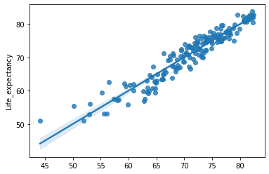

```python
model2 = sm.OLS(y, X3).fit()
print(model2.summary())
r=model2.predict(X3)
r=np.array(model2)
sns.regplot(model2.fittedvalues.copy(), y)
plt.show()
#Обучаем модель и  выводим описание данных и модели,строим график регрессионной модели
```

Интерпретация вывода модели и графика: Зависимой здесь является пременная Life_expectancy Использовался метод наименьших квадратов R-squared (коэффициент детерминации) равен 0,918, что означает, что приблизительно 91,8% вариации зависимой переменной (y) может быть объяснено независимыми переменными (X), используемыми в модели.Это высокий процент.

Adj. R-squared (скорректированный коэффициент детерминации) равен 0.917. Этот показатель учитывает количество независимых переменных и корректирует коэффициент детерминации в соответствии с числом используемых переменных. Обычно этот показатель более надежен, чем просто коэффициент детерминации, поскольку он может уменьшаться при добавлении "лишних" переменных, которые не вносят значительный вклад в модель.

Общее значение коэффициента детерминации в 0.91 указывает на то, что данная линейная регрессионная модель хорошо описывает отношение между зависимыми и независимыми переменными.Модель получилось точной,чем ближе R квадрат к единице,тем более точная модель.

Коэффициент для Adult_mortality равен -0,0764, что предполагает, что с каждым увеличением Adult_mortality на единицу ожидаемая продолжительность жизни уменьшается на 0,0764 единицы, сохраняя другие переменные постоянными. Коэффициент для Economy_status_Developed равен 2,8820, что означает, что в странах, классифицированных как "Развитые", ожидаемая продолжительность жизни в среднем на 2,8820 выше, чем в странах, классифицированных как "Развивающиеся", при сохранении других переменных постоянными.

Оба коэффициента имеют p-значения меньше 0,05, что указывает на то, что они статистически значимы на уровне 5%. Это означает, что мы можем отклонить нулевую гипотезу о том, что коэффициенты равны нулю, и заключить, что взаимосвязь между каждой независимой переменной и зависимой переменной является статистически значимой.

F-статистика подтверждает, что по крайней мере одна из независимых переменных имеет статистически значимую связь с зависимой переменной, и общая модель является статистически значимой, как показано очень малым значением p, связанным с F-статистикой.

В целом, эта модель предполагает, что как Adult_mortality, так и Economy_status_Developed являются важными предикторами ожидаемой продолжительности жизни, и вместе они объясняют значительную долю изменений в ожидаемой продолжительности жизни.